# Kaggle Learn

#### Machine Learning Level 2

Source: https://www.kaggle.com/learn/machine-learning  
Slide Command: jupyter nbconvert Presentation.ipynb --to slides --post serve

Presentor: Kavi Sekhon

### L1: Missing Value Introduction

Source: https://www.kaggle.com/dansbecker/handling-missing-values

```python
# Import pandas and our training data
import pandas as pd
main_file_path = 'Data/train.csv'
data = pd.read_csv(main_file_path)
```

```python
# View the total sum of null values
data.isnull().sum()
```

```
Id                  0
MSSubClass          0
MSZoning            0
LotFrontage       259
LotArea             0
Street              0
Alley            1369
LotShape            0
LandContour         0
Utilities           0
LotConfig           0
LandSlope           0
Neighborhood        0
Condition1          0
Condition2          0
BldgType            0
HouseStyle          0
OverallQual         0
OverallCond         0
YearBuilt           0
YearRemodAdd        0
RoofStyle           0
RoofMatl            0
Exterior1st         0
Exterior2nd         0
MasVnrType          8
MasVnrArea          8
ExterQual           0
ExterCond           0
Foundation          0
                 ...
BedroomAbvGr        0
KitchenAbvGr        0
KitchenQual         0
TotRmsAbvGrd        0
Functional          0
Fireplaces          0
FireplaceQu       690
GarageType         81
GarageYrBlt        81
GarageFinish       81
GarageCars          0
GarageArea          0
GarageQual         81
GarageCond         81
PavedDrive          0
WoodDeckSF          0
OpenPorchSF         0
EnclosedPorch       0
3SsnPorch           0
ScreenPorch         0
PoolArea            0
PoolQC           1453
Fence            1179
MiscFeature      1406
MiscVal             0
MoSold              0
YrSold              0
SaleType            0
SaleCondition       0
SalePrice           0
Length: 81, dtype: int64
```

### Null Value Solutions

##### 1) A Simple Option: Drop Columns with Missing Values

```python
# Copying the data into a pandas dataframe
original_data = pd.DataFrame(data)
```

```python
# Dropping any row with a missing value
data_without_missing_values = original_data.dropna(axis=1)
data_without_missing_values.head()
```

|  | Id | MSSubClass | MSZoning | LotArea | Street | LotShape | LandContour | Utilities | LotConfig | LandSlope | ... | EnclosedPorch | 3SsnPorch | ScreenPorch | PoolArea | MiscVal | MoSold | YrSold | SaleType | SaleCondition | SalePrice |
| --- | --- | --- | --- | --- | --- | --- | --- | --- | --- | --- | --- | --- | --- | --- | --- | --- | --- | --- | --- | --- | --- |
| 0 | 1 | 60 | RL | 8450 | Pave | Reg | Lvl | AllPub | Inside | Gtl | ... | 0 | 0 | 0 | 0 | 0 | 2 | 2008 | WD | Normal | 208500 |
| 1 | 2 | 20 | RL | 9600 | Pave | Reg | Lvl | AllPub | FR2 | Gtl | ... | 0 | 0 | 0 | 0 | 0 | 5 | 2007 | WD | Normal | 181500 |
| 2 | 3 | 60 | RL | 11250 | Pave | IR1 | Lvl | AllPub | Inside | Gtl | ... | 0 | 0 | 0 | 0 | 0 | 9 | 2008 | WD | Normal | 223500 |
| 3 | 4 | 70 | RL | 9550 | Pave | IR1 | Lvl | AllPub | Corner | Gtl | ... | 272 | 0 | 0 | 0 | 0 | 2 | 2006 | WD | Abnorml | 140000 |
| 4 | 5 | 60 | RL | 14260 | Pave | IR1 | Lvl | AllPub | FR2 | Gtl | ... | 0 | 0 | 0 | 0 | 0 | 12 | 2008 | WD | Normal | 250000 |

5 rows × 62 columns

##### 2) A Better Option: Imputation

```python
# Creating a list of numerical columns
numeric_columns  = list(original_data.select_dtypes(include=[int, float]).columns)

# Import the imputer class from sklearn
from sklearn.preprocessing import Imputer

# Assign the Imputer to a variable
my_imputer =  Imputer()

# Fit and transform numerical columns with imputed values
data_with_imputed_values = my_imputer.fit_transform(original_data[numeric_columns])

# View the imputated values
data_with_imputed_values
```

```
array([[  1.00000000e+00,   6.00000000e+01,   6.50000000e+01, ...,
          2.00000000e+00,   2.00800000e+03,   2.08500000e+05],
       [  2.00000000e+00,   2.00000000e+01,   8.00000000e+01, ...,
          5.00000000e+00,   2.00700000e+03,   1.81500000e+05],
       [  3.00000000e+00,   6.00000000e+01,   6.80000000e+01, ...,
          9.00000000e+00,   2.00800000e+03,   2.23500000e+05],
       ...,
       [  1.45800000e+03,   7.00000000e+01,   6.60000000e+01, ...,
          5.00000000e+00,   2.01000000e+03,   2.66500000e+05],
       [  1.45900000e+03,   2.00000000e+01,   6.80000000e+01, ...,
          4.00000000e+00,   2.01000000e+03,   1.42125000e+05],
       [  1.46000000e+03,   2.00000000e+01,   7.50000000e+01, ...,
          6.00000000e+00,   2.00800000e+03,   1.47500000e+05]])
```

##### 3) An Extention to Imputation

```python
# make a copy to avoid changing original data (when Imputing)
new_data = original_data[numeric_columns].copy()
```

```python
# Finding features with missing null values
cols_with_missing = (col for col in new_data.columns
                    if new_data[col].isnull().any())

# creating pandas dataframe with only missing null values
for col in cols_with_missing:
  new_data[col + '_was missing'] = new_data[col].isnull()

# Imputating featurse with missing data
my_imputer = Imputer()
new_data = my_imputer.fit_transform(new_data)
```

### Comparing All Null Value Solution

##### Basic Problem Set-up

```python
# Import pandas and sklean modules
import pandas as pd
from sklearn.ensemble import RandomForestRegressor
from sklearn.metrics import mean_absolute_error
from sklearn.model_selection import train_test_split

# Import data
melb_data = pd.read_csv('Data/melb_data.csv')

# Set target, and predictors
melb_target = melb_data.Price
melb_predictors = melb_data.drop(['Price'], axis=1)

# For the sake of keeping the example simple, we'll use only numeric predictors.
melb_numeric_predictors = melb_predictors.select_dtypes(exclude=['object'])
```

##### Creating Function to Measure Quality of An Approach

```python
# Import RandomForestModel, Mean Absolute Error, and Train-Test Split
from sklearn.ensemble import RandomForestRegressor
from sklearn.metrics import mean_absolute_error
from sklearn.model_selection import train_test_split

# Split the data by train-test split
X_train, X_test, y_train, y_test = train_test_split(melb_numeric_predictors,
                                                    melb_target,
                                                    train_size=0.7,
                                                    test_size=0.3,
                                                    random_state=0)

# Creating a function to score our model that includeds imputated data
def score_dataset(X_train, X_test, y_train, y_test):
  model = RandomForestRegressor()
  model.fit(X_train, y_train)
  preds = model.predict(X_test)
  return (mean_absolute_error(y_test, preds))
```

##### 1) Get Model Score from Dropping Columns with Missing Values

```python
# Generating a list of column for columns with missing data
cols_with_missing = [col for col in X_train.columns
                     if X_train[col].isnull().any()]

# Ceating predictor dataframe without columns that contain missing values
reduced_X_train = X_train.drop(cols_with_missing, axis=1)
reduced_X_test = X_test.drop(cols_with_missing, axis=1)

# Using our scoring function to print out our accuracy measure
print('Mean Absolute Error form dropping columsn with Missing Values:')
print(score_dataset(reduced_X_train, reduced_X_test, y_train, y_test))
```

```
Mean Absolute Error form dropping columsn with Missing Values:
352643.478529
```

##### 2) Get Model Score from imputation

```python
# Creating testing and training data using Imputation
from sklearn.preprocessing import Imputer

my_impture = Imputer()
imputed_X_train = my_imputer.fit_transform(X_train)
imputed_X_test = my_imputer.transform(X_test)


# Using our scoring function to print out our accuracy measure for Imputation
print('Mean Absolute Error from Impuation:')
print(score_dataset(imputed_X_train, imputed_X_test, y_train, y_test))
```

```
Mean Absolute Error from Impuation:
202816.389092
```

##### 3) Get Score from Imputation with Extra Columns Showing What Was Imputed

```python
# Copy our imputed training and test data from the last example
imputed_X_train_plus = X_train.copy()
imputed_X_test_plus = X_test.copy()

# Generating a list of columns that containe missing values
cols_with_missing =  (col for col in X_train.columns
                     if X_train[col].isnull().any())

# creating a seperate list of columns of null values in the train and test data
for col in cols_with_missing:
  imputed_X_train_plus[col + '_was_missing'] = imputed_X_train_plus[col].isnull()
  imputed_X_test_plus[col + '_was_missing'] = imputed_X_test_plus[col].isnull()


# Impuation fitting and transforming data for both train and test set
my_imputer = Imputer()
imputed_X_train_plus = my_imputer.fit_transform(imputed_X_train_plus)
imputed_X_test_plus = my_imputer.fit_transform(imputed_X_test_plus)

print("Mean Absolute Error from Imputation while Track What Was Imputed:")
print(score_dataset(imputed_X_train_plus, imputed_X_test_plus, y_train, y_test))
```

```
Mean Absolute Error from Imputation while Track What Was Imputed:
205427.982678
```

### L2: Using Categorical Data with One Hot Encoding

Source: https://www.kaggle.com/dansbecker/using-categorical-data-with-one-hot-encoding

```python
# Read the data
import pandas as pd
train_data = pd.read_csv('Data/train.csv')
test_data = pd.read_csv('Data/test.csv')

# Drop the houses where the target is missing
train_data.dropna(axis=0, subset=['SalePrice'], inplace=True)

# Creating the target series
target = train_data.SalePrice


# Generating a list of columns that containe missing values
cols_with_missing = [col for col in train_data.columns
                    if train_data[col].isnull().any()]

# Creatinp the training and testing dataframe
candidate_train_predictors = train_data.drop(['Id', 'SalePrice'] + cols_with_missing, axis=1)
candidate_test_predictors = test_data.drop(['Id'] + cols_with_missing, axis=1)
```

```python
# Tangent: Dataframe Dtypes

train_predictors.dtypes.sample(10)
```

```
GrLivArea        int64
Fireplaces       int64
Foundation      object
BldgType        object
BsmtFullBath     int64
Functional      object
KitchenQual     object
BsmtFinSF1       int64
LotArea          int64
BsmtHalfBath     int64
dtype: object
```

```python
# creating a list of colums that had dtype equal to object
# and number of unique values in series is less than 10
low_cardinality_cols = [cname for cname in candidate_train_predictors.columns if
                                candidate_train_predictors[cname].nunique() < 10 and
                                candidate_train_predictors[cname].dtype == "object"]

# creating a list of colums that use either a int of float dtype
numeric_cols = [cname for cname in candidate_train_predictors.columns if
                                candidate_train_predictors[cname].dtype in ['int64', 'float64']]

# creating a list columns including numrecial and low cardinality features
my_cols = low_cardinality_cols + numeric_cols

# creating the trainin data
train_predictors = candidate_train_predictors[my_cols]

# creating the testing data
test_predictors = candidate_test_predictors[my_cols]
```

```python
### current dataframe
train_predictors.head(5)
```

|  | MSZoning | Street | LotShape | LandContour | Utilities | LotConfig | LandSlope | Condition1 | Condition2 | BldgType | ... | GarageArea | WoodDeckSF | OpenPorchSF | EnclosedPorch | 3SsnPorch | ScreenPorch | PoolArea | MiscVal | MoSold | YrSold |
| --- | --- | --- | --- | --- | --- | --- | --- | --- | --- | --- | --- | --- | --- | --- | --- | --- | --- | --- | --- | --- | --- |
| 0 | RL | Pave | Reg | Lvl | AllPub | Inside | Gtl | Norm | Norm | 1Fam | ... | 548 | 0 | 61 | 0 | 0 | 0 | 0 | 0 | 2 | 2008 |
| 1 | RL | Pave | Reg | Lvl | AllPub | FR2 | Gtl | Feedr | Norm | 1Fam | ... | 460 | 298 | 0 | 0 | 0 | 0 | 0 | 0 | 5 | 2007 |
| 2 | RL | Pave | IR1 | Lvl | AllPub | Inside | Gtl | Norm | Norm | 1Fam | ... | 608 | 0 | 42 | 0 | 0 | 0 | 0 | 0 | 9 | 2008 |
| 3 | RL | Pave | IR1 | Lvl | AllPub | Corner | Gtl | Norm | Norm | 1Fam | ... | 642 | 0 | 35 | 272 | 0 | 0 | 0 | 0 | 2 | 2006 |
| 4 | RL | Pave | IR1 | Lvl | AllPub | FR2 | Gtl | Norm | Norm | 1Fam | ... | 836 | 192 | 84 | 0 | 0 | 0 | 0 | 0 | 12 | 2008 |

5 rows × 57 columns

```python
### printing number of feature train_predictors
print('Number for features:',train_predictors.shape[1])
```

```
Number for features: 57
```

### Using One Hot Encoding

```python
one_hot_encoded_training_predictors = pd.get_dummies(train_predictors)
one_hot_encoded_training_predictors.head(5)
```

|  | MSSubClass | LotArea | OverallQual | OverallCond | YearBuilt | YearRemodAdd | BsmtFinSF1 | BsmtFinSF2 | BsmtUnfSF | TotalBsmtSF | ... | SaleType_ConLw | SaleType_New | SaleType_Oth | SaleType_WD | SaleCondition_Abnorml | SaleCondition_AdjLand | SaleCondition_Alloca | SaleCondition_Family | SaleCondition_Normal | SaleCondition_Partial |
| --- | --- | --- | --- | --- | --- | --- | --- | --- | --- | --- | --- | --- | --- | --- | --- | --- | --- | --- | --- | --- | --- |
| 0 | 60 | 8450 | 7 | 5 | 2003 | 2003 | 706 | 0 | 150 | 856 | ... | 0 | 0 | 0 | 1 | 0 | 0 | 0 | 0 | 1 | 0 |
| 1 | 20 | 9600 | 6 | 8 | 1976 | 1976 | 978 | 0 | 284 | 1262 | ... | 0 | 0 | 0 | 1 | 0 | 0 | 0 | 0 | 1 | 0 |
| 2 | 60 | 11250 | 7 | 5 | 2001 | 2002 | 486 | 0 | 434 | 920 | ... | 0 | 0 | 0 | 1 | 0 | 0 | 0 | 0 | 1 | 0 |
| 3 | 70 | 9550 | 7 | 5 | 1915 | 1970 | 216 | 0 | 540 | 756 | ... | 0 | 0 | 0 | 1 | 1 | 0 | 0 | 0 | 0 | 0 |
| 4 | 60 | 14260 | 8 | 5 | 2000 | 2000 | 655 | 0 | 490 | 1145 | ... | 0 | 0 | 0 | 1 | 0 | 0 | 0 | 0 | 1 | 0 |

5 rows × 159 columns

### Comparing one-hot encoded model vs non-categorical mode1

```python
# Importing RandomForestRegressor, and cross val score
from sklearn.model_selection import cross_val_score
from sklearn.ensemble import RandomForestRegressor

# A quick function that return the our accuracy metrics for given training values
def get_mae(X, y):
  return -1 * cross_val_score(RandomForestRegressor(50),
                             X, y, scoring='neg_mean_absolute_error').mean()

# creating a dataframe with numeical values
predictors_without_categoricals = train_predictors.select_dtypes(exclude=['object'])

# Viewing mae with and without one-host encoding using a RandomForestRegressor
mae_without_categoricals = get_mae(predictors_without_categoricals, target)
mae_one_hot_encoded = get_mae(one_hot_encoded_training_predictors, target)

print('Mean Absolute Error when Dropping Categoricals: ' + str(int(mae_without_categoricals)))
print('Mean Abslute Error with One-Hot Encoding: ' + str(int(mae_one_hot_encoded)))
```

```
Mean Absolute Error when Dropping Categoricals: 18490
Mean Abslute Error with One-Hot Encoding: 18238
```

### Applying to Multiple Files

```python
# Encoding training and testing data seperately
one_hot_encoded_training_predictors = pd.get_dummies(train_predictors)
one_hot_encoded_test_predictors = pd.get_dummies(test_predictors)

# This was cool, I was not aware of this
final_train, final_test = one_hot_encoded_training_predictors.align(
  one_hot_encoded_test_predictors, join='left', axis=1)
```

# L3: Learning to Use XGBoost

### Example - XG Boost

```python
# Model Setup
import pandas as pd
from sklearn.model_selection import train_test_split
from sklearn.preprocessing import Imputer

# Import Data, set Target & predictators
data = pd.read_csv('Data/train.csv')
data.dropna(axis=0, subset=['SalePrice'], inplace=True)
y = data.SalePrice
X = data.drop(['SalePrice'], axis=1).select_dtypes(exclude=['object'])
train_X, test_X, train_y, test_y = train_test_split(X.as_matrix(), y.as_matrix(), test_size=0.25)

# Imputate training and testing data
my_imputer = Imputer()
train_X = my_imputer.fit_transform(train_X)
test_X = my_imputer.transform(test_X)
```

```python
# Importing the XGB Regressor from XGBoost
from xgboost import XGBRegressor

# Assiinging my model
my_model = XGBRegressor()

# I set the verbose to True, because logs are cool, initially
my_model.fit(train_X, train_y, verbose=True)
```

```
XGBRegressor(base_score=0.5, booster='gbtree', colsample_bylevel=1,
       colsample_bytree=1, gamma=0, learning_rate=0.1, max_delta_step=0,
       max_depth=3, min_child_weight=1, missing=None, n_estimators=100,
       n_jobs=1, nthread=None, objective='reg:linear', random_state=0,
       reg_alpha=0, reg_lambda=1, scale_pos_weight=1, seed=None,
       silent=True, subsample=1)
```

```python
# make predictions on training dataset
predictions = my_model.predict(test_X)

# print mae for training set
from sklearn.metrics import mean_absolute_error
print('Mean Absolute Error:' + str(mean_absolute_error(predictions, test_y)))
```

```
Mean Absolute Error:16682.41814
```

##### Model Tuning

```python
# Fitting model parameters n_esimators
my_model = XGBRegressor(n_emtimators=1000)
my_model.fit(train_X, train_y, early_stopping_rounds=5,
            eval_set=[(test_X, test_y)], verbose=False)
```

```
XGBRegressor(base_score=0.5, booster='gbtree', colsample_bylevel=1,
       colsample_bytree=1, gamma=0, learning_rate=0.1, max_delta_step=0,
       max_depth=3, min_child_weight=1, missing=None, n_emtimators=1000,
       n_estimators=100, n_jobs=1, nthread=None, objective='reg:linear',
       random_state=0, reg_alpha=0, reg_lambda=1, scale_pos_weight=1,
       seed=None, silent=True, subsample=1)
```

```python
# Fitting model parameters with a learning rate
my_model = XGBRegressor(n_estimators=1000, learning_rate=0.05)
my_model.fit(train_X, train_y, early_stopping_rounds=5,
            eval_set=[(test_X, test_y)], verbose=False)
```

```
XGBRegressor(base_score=0.5, booster='gbtree', colsample_bylevel=1,
       colsample_bytree=1, gamma=0, learning_rate=0.05, max_delta_step=0,
       max_depth=3, min_child_weight=1, missing=None, n_estimators=1000,
       n_jobs=1, nthread=None, objective='reg:linear', random_state=0,
       reg_alpha=0, reg_lambda=1, scale_pos_weight=1, seed=None,
       silent=True, subsample=1)
```

# L4: Partial Dependence Plots

Source: https://www.kaggle.com/dansbecker/partial-dependence-plots

- Partial dependence plots show how each variable or predictor affects the model's predictions
- The partial dependence plot is calculated only after the model has been fit.

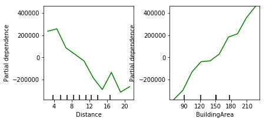

```python
# Jupyter Command sto show visualization inline, after the cell
%matplotlib inline

# Import modules
import pandas as pd
from sklearn.ensemble import GradientBoostingRegressor, GradientBoostingClassifier
from sklearn.ensemble.partial_dependence import partial_dependence, plot_partial_dependence
from sklearn.preprocessing import Imputer

# feature selcetion of our interested columns
cols_to_use = ['Distance', 'Landsize', 'BuildingArea']

# Creating a fucntion that call some data
def get_some_data():
    data = pd.read_csv('Data/melb_data.csv')
    y = data.Price
    X = data[cols_to_use]
    my_imputer = Imputer()
    imputed_X = my_imputer.fit_transform(X)
    return imputed_X, y

# Return training data from "get_some_data" function
X, y = get_some_data()

# Use the GradienBoostReqgressor
my_model = GradientBoostingRegressor()

# Fit the model
my_model.fit(X, y)

# Creating Partial Dependence plots with SKlearn
my_plts = plot_partial_dependence(my_model, features=[0,2],
                                 X=X, feature_names=cols_to_use,
                                 grid_resolution=10)
# View my plots
my_plts
```

### Another Example: Titanic Dataest

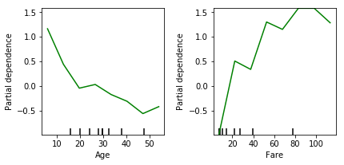

```python
titanic_data = pd.read_csv('Data/titanic.csv')
titanic_y = titanic_data.Survived
clf = GradientBoostingClassifier()
titanic_X_colns = ['PassengerId','Age','Fare',]
titanic_X = titanic_data[titanic_X_colns]
my_imputer = Imputer()
imputed_titanic_X = my_imputer.fit_transform(titanic_X)

clf.fit(imputed_titanic_X, titanic_y)
titanic_plots = plot_partial_dependence(clf, features=[1,2], X=imputed_titanic_X,
                                       feature_names=titanic_X_colns, grid_resolution=8)
```

# L5: Pipelines

Source: https://www.kaggle.com/dansbecker/pipelines

Pipelines are a simple way to keep your data processing and modeling code organized. Specifically, a pipeline bundles preprocessing and modeling steps so you can use the whole bundle as if it were a single step.

Many data scientists hack together models without pipelines, but Pipelines have some important benefits. Those include:

- Cleaner Code: You won't need to keep track of your training (and validation) data at each step of processing. Accounting for data at each step of processing can get messy. With a pipeline, you don't need to manually keep track of each step.
- Fewer Bugs: There are fewer opportunities to mis-apply a step or forget a pre-processing step.
- Easier to Productionize: It can be surprisingly hard to transition a model from a prototype to something deployable at scale. We won't go into the many related concerns here, but pipelines can help.
- More Options For Model Testing: You will see an example in the next tutorial, which covers cross-validation.

```python
import pandas as pd
from sklearn.model_selection import train_test_split

# Read the data in and split it into training and testing group
data = pd.read_csv('Data/melb_data.csv')
cols_to_use = ['Rooms', 'Distance', 'Landsize', 'BuildingArea', 'YearBuilt']
X = data[cols_to_use]
y = data.Price
train_X, test_X, train_y, test_y = train_test_split(X,y)
```

```python
# Import the stages of the DataFrame
from sklearn.ensemble import RandomForestRegressor
from sklearn.pipeline import make_pipeline
from sklearn.preprocessing import Imputer

# Creating the Pipeline
my_pipeline = make_pipeline(Imputer(), RandomForestRegressor())
```

```python
# Fit the datframe to your pipeline
my_pipeline.fit(train_X, train_y)

# View the predictions from the dataframe
predictions = my_pipeline.predict(test_X)
predictions
```

```
array([ 2244200.        ,  1055998.21587726,   830100.        , ...,
         837500.        ,  1396800.        ,  1954600.        ])
```

# L6: Cross Validation

Source: https://www.kaggle.com/dansbecker/cross-validation

```python
import pandas as pd
from sklearn.ensemble import RandomForestRegressor
from sklearn.pipeline import make_pipeline
from sklearn.preprocessing import Imputer

#  Import trainin and testing datasets
data = pd.read_csv('Data/melb_data.csv')
cols_to_use = ['Rooms', 'Distance', 'Landsize', 'BuildingArea', 'YearBuilt']
X = data[cols_to_use]
y = data.Price

# Create a pipeline
my_pipeline = make_pipeline(Imputer(), RandomForestRegressor())
```

```python
# Sklearn 'cross_val_score metric' can give a cross_valitated score for any dataset
from sklearn.model_selection import cross_val_score
scores = cross_val_score(my_pipeline, X, y, scoring='neg_mean_absolute_error')
print(scores)
```

```
[-324070.99804702 -300938.71715819 -279986.25416915]
```

```python
# Taking the mean of the scores, as the best performance measure
print('Mean Absolute Error %2f' %(-1 * scores.mean()))
```

```
Mean Absolute Error 301665.323125
```

# L7: Data Leakage

```python
import pandas as pd

# Import credit card data
data = pd.read_csv('Data/AER_credit_card_data.csv',
                   true_values = ['yes'],
                   false_values = ['no'])
data.head(n=5)
```

|  | card | reports | age | income | share | expenditure | owner | selfemp | dependents | months | majorcards | active |
| --- | --- | --- | --- | --- | --- | --- | --- | --- | --- | --- | --- | --- |
| 0 | True | 0 | 37.66667 | 4.5200 | 0.033270 | 124.983300 | True | False | 3 | 54 | 1 | 12 |
| 1 | True | 0 | 33.25000 | 2.4200 | 0.005217 | 9.854167 | False | False | 3 | 34 | 1 | 13 |
| 2 | True | 0 | 33.66667 | 4.5000 | 0.004156 | 15.000000 | True | False | 4 | 58 | 1 | 5 |
| 3 | True | 0 | 30.50000 | 2.5400 | 0.065214 | 137.869200 | False | False | 0 | 25 | 1 | 7 |
| 4 | True | 0 | 32.16667 | 9.7867 | 0.067051 | 546.503300 | True | False | 2 | 64 | 1 | 5 |

```python
from sklearn.pipeline import make_pipeline
from sklearn.ensemble import RandomForestClassifier
from sklearn.model_selection import cross_val_score

# Set target and predictors
y = data.card
X = data.drop(['card'], axis=1)

# Since there was no preprocessing, we didn't need a pipeline here.
# Used anyway as best practice.

# Creating a model Pipeline
modeling_pipeline = make_pipeline(RandomForestClassifier())
cv_scores = cross_val_score(modeling_pipeline, X, y, scoring='accuracy')
print("Cross-val accuracy: %f" %cv_scores.mean())
```

```
Cross-val accuracy: 0.980284
```

```python
# Grouping expenditure data based on card and non-card holder
expenditures_cardholders = data.expenditure[data.card]
expenditures_noncardholders = data.expenditure[~data.card]

# Printing Mean for card expentiture grouping
print('Fraction of those who received a card with no expenditures: %.2f' \
      %(( expenditures_cardholders == 0).mean()))
print('Fraction of those who received a card with no expenditures: %.2f' \
      %((expenditures_noncardholders == 0).mean()))
```

```
Fraction of those who received a card with no expenditures: 0.02
Fraction of those who received a card with no expenditures: 1.00
```

```python
# Author identifies features that may be causing leaks
potential_leaks = ['expenditure', 'share', 'active', 'majorcards']

# Drop leaky features from dataframe
X2 = X.drop(potential_leaks, axis=1)

# computed cross_val_scores for our pipeline
cv_scores = cross_val_score(modeling_pipeline, X2, y, scoring='accuracy')

# print the mean cross_val_score
print("Cross-val accuracy: %f" %cv_scores.mean())
```

```
Cross-val accuracy: 0.803641
```